# NYU SURP 2019 R course Class 4: Vectors cont’d, missing values, and logical operations

Eugene Plavskin

Grace Avecilla

Tobi Shraink

07/02/2019

# Review: vectors, functions, and types

## Vectors and functions

```r
# Create a vector containing any 4 numbers

# Calculate the sum of that vector and print it out on the screen
```

Notice that lots of functions work on vectors!

## Vector types

What if we wanted to store the number 3 and the character “3” together in a vector?

```r
# Create a vector, mix_vector, with 3 and "3"

# check the type of mix_vector

# why is this happening (check the documentation of c)
```

# Making consecutive sequences

Often you want to make a vector of integers.You can do this using a colon between two numbers. The number before the colon tells R where to start the sequence, and the number after tells it where to end. For example, if you type `2:5` into the console, you should see every integer from 2 to 5 printed.

```r
#try making a sequence of numbers using :
```

One really useful thing we can do in R is make vectors of evenly spaced numbers. To do this, we can use the `seq()` function. Let’s try to use the built-in R documentation of `seq()` to figure out how to use it.

```r
# On your own:
# Based on the documentation from of seq, make the sequence: 1, 2, 3, 4

# In pairs:
# Now make the sequence: 2, 2.5, 3, 3.5

# Identify what values are corresponding to what arguments
```

*Skip if behind*: Seq can work in both directions (i.e., the numbers don’t have to be going up)

```r
# Use seq to make the following sequence: 5, 3, 1, -1
```

There are three things that make seq really powerful compared to just typing out vectors of numbers by hand:

1. It can generate reaaaaaally long sequences of numbers
2. Like all functions, it can use variables as inputs, which means you don’t have to change your whole code every time you change your mind about what numbers you’re interested in working with
3. When you want to make a vector of a certain length, it will do the math for you of what the spacing between your numbers needs to look like

Relatedly, a really useful function in R is `length()`. It can tell you how long your vector is (how many elements are in your vector)

```r
# Use length() to find out how long the first vector you made in this class is
```

# Operations on vectors of numbers

One of the best things about vectors that will come up again and again soon is that you can do operations on them, just like with numbers. Here’s one example:

```r
# Create a variable holding a vector that contains an evenly spaced sequence of
# five numbers, from 2 to 4

# Add 3 to the vector. What happens?
```

You can also add vectors together!

```r
vector_a <- c(1,2,3)
vector_b <- c(4,5,6)

# Add vector_a and vector_b

# What is happening? How is this different from adding 3 to a vector?
```

# Getting specific elements of vectors

Often, it’s really useful to find out what the value of a specific position (or *index*) in a vector is. R makes this easy.

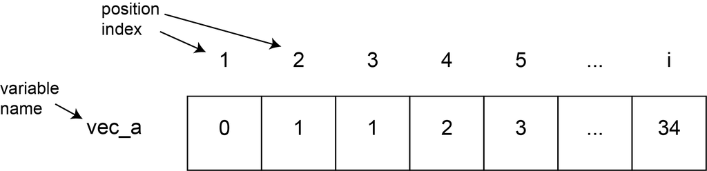

Let’s create a really long vector and ask R to tell us about specific points along that vector.

```r
# Create three variables, first_num, last_num, and num_of_elements
# The first two can be whatever numbers you want, num_of_elements should be 100
# Actually: DON'T use 1 for first_num, and don't use 100 for last_num. Be creative.

# Use the function we learned about at the beginning of class to make a sequence
# of length num_of_elements starting at first_num and going to last_num, and
# put that in a vector called long_vector

# Check the length of the vector you just created
```

To access the number at a specific position, we can use square brackets!

```r
# Let's check what the first number in long_vector is
print(long_vector[1])

# Now check what the 32nd number in long_vector is
```

*Skip if low on time*

```r
# Now check what the last number in long_vector is
# (bonus: do this using a variable you've already created, rather than just
# typing out 100)
```

You don’t have to just provide a single number as in index (the thing inside the square brackets); vectors work too!

```r
# Print out the 4th, 5th, and 6th number in long_vector
print(long_vector[c(4,5,6)])
# Use something we have learned today to specificy 4, 5, 6
```

*skip if running low on time*

Actually, we can get even more creative here. Let’s say you wanted to create a vector that had inside it *every other number* from *long_vector* (*i.e.* the 1st, 3rd, 5th, etc numbers that are in *long_vector*). Let’s try this. Hint: you can use `seq()` to create a vector of positions (*indices*) that you then use to get the positions you want from long_vector

```r
# Create position_vector, which will hold the positions you want to get out of
# long_vector (i.e. c(1,3,5,....))

# Use long_vector together with position_vector to create shorter_vector, which
# will hold every othern number from long_vector

# print out shorter_vector
```

# Converting between numeric and character types

Finally, it’s sometimes really helpful to be able to switch something between a numeric and a character type. Let’s say you import some data and your computer insists on thinking it’s letters, when it is clearly numbers (this happens a lot!) We can use the `as.numeric()` function to set things right.

```r
bad_numeric_vector <- c('1','3','4','7','11')

# check the type of bad_numeric_vector

# why is it not numeric?

# use as.numeric() to create a new vector, good_numeric_vector, which has all
# the values from bad_numeric_vector but as numbers instead of characters

# check the type of good_numeric_vector
```

We can also do this change backwards. Based on what you saw right above, what do you think the function is called that converts numeric values to character type?

```r
num_vector <- c(81, 243, 729)

# convert num_vector to a character vector
```

# When we get missing values

A **HUGE** part of analyzing real scientific data is dealing with missing values. There are lots of ways we can get missing values; these are probably the most common:

- When we try to get R to do a nonsensical thing
- When we perform some super taboo math operation
- When we are using real data and we didn’t collect every observation (*eg* you measured the height of a bunch of plants every week but by the third week, some of them died)

Every programming language has its own special way of representing ‘missing’ data; R, ever so special, uses two: *NA* or *NaN*, depending on the situation; don’t worry about the difference, I (Eugene) literally learned it while preparing this class, after 5 years of programming in R.

Let’s take a look at how these missing values work.

## Performing nonsensical operations

Let’s try to see what R does when we ask it to do something that clearly doesn’t make sense. Remember that we can ask R to convert a list of characters to numbers. Let’s try that again.

```r
weird_number_vector <- c('1', '4', 'koala', '18')

# Convert weird_number_vector to numeric type, and print out the result
```

## Taboo math operations

Another way to get missing values is to perform a math operation that R doesn’t like. Let’s try doing this. Remember that we can perform operations on vectors, e.g. adding two vectors to each other. Let’s try dividing vectors this way.

```r
vector_1 <- c(1, 2, 0, 3, 0, -5)
vector_2 <- c(0, -3, 1, 6, 0, 0)

# What do you think you'll get if you divide vector_1 by vector_2?

# Try it
```

## Real missing data

Finally, you can enter NA into your vector, just like you would any other value

```r
# Create a vector, data_vector, which has some numbers and at least one NA value

# What happens if you take the sum of data_vector?
```

Lots of functions in R, including `sum()`, have a way of dealing with missing data automatically. There are lots of times when we may want to just ignore the missing values and work with the rest of the data we have. Take a look at the documentation for `sum()`; do you see anything in there that might suggest how you could get the function to ignore missing values and take the sum of *data_vector* anyways?

```r
# Try using sum() to get the sum of the non-missing values in data_vector
```